# Houston City Council: local ideal points, 2000–2026

Pooled roll calls, 2000–2026

Author

Boris Shor

Updated

October 8, 2026

This analysis places **77 Houston officials**, including five mayors, who cast qualifying council votes between 2000 and 2026 on one pooled voting scale. The tabs follow **elected councils**, with two-year terms before 2016 and four-year terms thereafter. The 2000–2003 votes provide substantial coverage of the earliest councils. Independently researched affiliations and district presidential voting provide external checks. The separate [2021–2025 report](https://bshor.github.io/reports/houston-city-council/houston-report.html) remains available, as does an interactive dashboard for this expanded fit.

**77 officials**  
Pooled across 2000–2026

**5 mayors**  
Brown through Whitmire

**939 roll calls**  
Contested council decisions

**13,785 votes**  
Recorded yeas and nays

## Dataset and construction

The published roll-call votes cover January 2000 to May 2026, with 39,463 council actions and 626,483 member responses. The analysis uses the [preserved council-votes data](https://github.com/MyTownRepo/council-votes/tree/research/houston-2000-2003); the technical appendix records the exact source version. Of these actions, 939 have at least two yeas and two nays. Requiring each person to cast at least seven qualifying yea/nay votes leaves all 939 actions, 77 members, and 13,785 observed votes. Only two one-vote name variants fall below the threshold; Mayor Lee P. Brown contributes 368 votes.

| Measure | Value |
| --- | --- |
| Source council actions | 39,463 |
| Source member rows | 626,483 |
| Qualifying divided actions | 939 |
| Officials after seven-vote minimum | 77 |
| Observed yea/nay votes | 13,785 |

The mayor votes as part of the council. Today’s 17 voting officials are the mayor, eleven district members, and five at-large members; the earlier council had nine district seats ([Houston’s 2003 almanac](https://www.houstontx.gov/planning/Publications/2003_almanac.pdf)). A person is missing, not coded nay, when absent, departed, or omitted from an explicit roll call. Only actions with at least two recorded yeas and two recorded nays enter the scale. Most council business is unanimous or close to it, so these actions are a selected subset of policy decisions rather than a summary of everything the council did. The bar chart shows how many qualifying disagreements are observed for each elected council.

The period tabs follow the terms produced by Houston’s regular elections. The city had **two-year elected terms through 2014–2015**; voters adopted **four-year terms effective January 2016** ([Houston’s 2003 almanac](https://www.houstontx.gov/planning/Publications/2003_almanac.pdf); [2016 city financial report](https://houstontx.gov/controller/cafr/cafr2016printerfriendly.pdf)). Terms begin January 2 ([City Council](https://www.houstontx.gov/council/)), and the [City Secretary’s election record](https://www.houstontx.gov/citysec/elections/electionsindex.html) identifies the election years. The first tabbed council was elected in 1999 and is observed from January 2000; the 2023-elected council is observed only through May 2026. A vacancy or special election changes a member within an elected council, not the council’s term boundary.

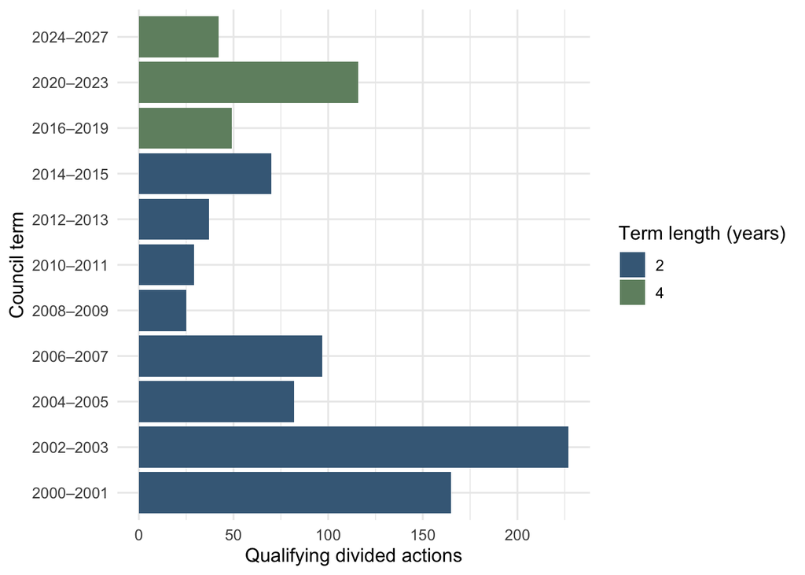

Qualifying divided actions by elected council. The 2024–2027 council is observed only through May 2026; four-year terms also cover twice the calendar time of earlier terms.

Five independently verified divided actions are present in the published votes. We corrected three transcription errors for this analysis: one June 2024 attendance entry and two late-2025 roll-call lists. The underlying data release remains unchanged. Absences and other unrecorded responses remain missing, not nays.

## Results

### 2024–2027 council

An **ideal point** summarizes voting similarity on contested roll calls: nearby members usually take the same side; distant members more often oppose one another. The pooled fit gives each of the 77 retained officials one position across all the years in which that person appears. The chart shows everyone with a qualifying vote so far in the council elected in 2023; their positions are estimated from the entire 2000–2026 matrix. Amy Peck is displayed on the positive side by convention. The units are specific to this Houston sample and cannot be compared numerically with other cities.

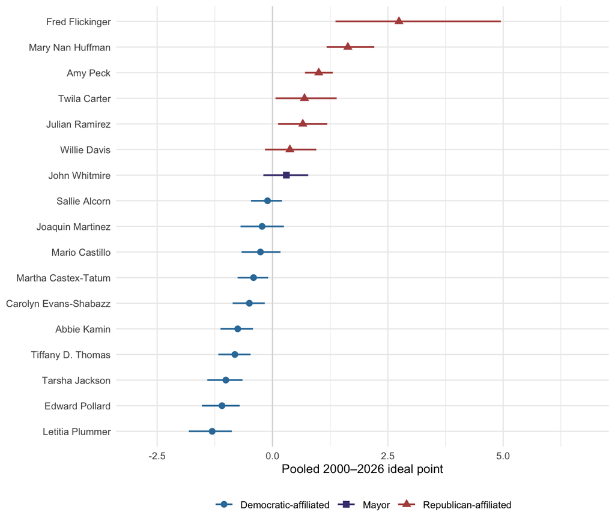

2024–2027 council, observed through May 2026. Positions come from the pooled fit. Bars are 95% posterior intervals. Affiliation colors use our external research coding, not the published roll-call votes or official nonpartisan ballots.

The positive end remains Republican-affiliated; Plummer, Pollard, Jackson, and Thomas are at the negative end. Most positions in the middle overlap.

### The mayors

The expanded record adds **Lee P. Brown** (-1.19) alongside **Bill White** (-0.43), **Annise Parker** (-0.59), **Sylvester Turner** (-0.68), and **John Whitmire** (0.30). Brown is the most negative of the five on this voting dimension. Turner sits with the Democratic district members who formed his governing majority. Whitmire is nearer the center, alongside Republican-endorsed at-large members elected in 2023. His placement is consistent with the moderate, public-safety and fiscal-restraint themes of his campaign; on the I-45 sale he voted with Republican-affiliated members. These positions describe observed coalitions, not complete governing platforms.

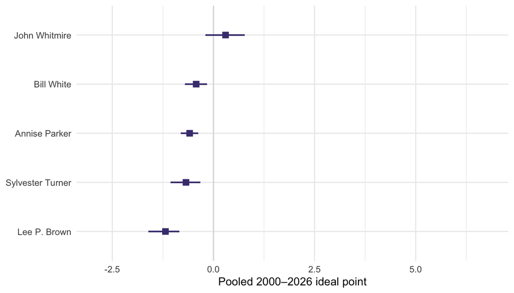

All five fitted mayors on the same pooled axis. Bars are 95% posterior intervals.

Because the mayor votes with the council, each mayor can be set against the members he or she presided over. The table covers only councils in which the person actually held the mayoralty — Parker’s earlier council service is excluded — and takes the median of the members serving alongside, mayors themselves excluded from that median.

| Mayor | Council | Mayor position | Council median | Mayor − median | Other members |
| --- | --- | --- | --- | --- | --- |
| Lee P. Brown | 2000–2001 | -1.19 | 0.43 | -1.62 | 13 |
| Lee P. Brown | 2002–2003 | -1.19 | 0.43 | -1.62 | 13 |
| Bill White | 2004–2005 | -0.43 | -0.12 | -0.30 | 14 |
| Bill White | 2006–2007 | -0.43 | -0.36 | -0.06 | 15 |
| Bill White | 2008–2009 | -0.43 | -0.45 | +0.02 | 15 |
| Annise Parker | 2010–2011 | -0.59 | -0.34 | -0.25 | 14 |
| Annise Parker | 2012–2013 | -0.59 | -0.33 | -0.25 | 17 |
| Annise Parker | 2014–2015 | -0.59 | -0.26 | -0.33 | 16 |
| Sylvester Turner | 2016–2019 | -0.68 | -0.17 | -0.51 | 17 |
| Sylvester Turner | 2020–2023 | -0.68 | -0.39 | -0.29 | 18 |
| John Whitmire | 2024–2027 | 0.30 | -0.24 | +0.54 | 16 |

Brown, White, Parker, and Turner sit to the negative side of their councils’ medians in most of their terms. **Whitmire sits to the right** of the members elected with him, by +0.54 on this scale. The table compares each mayor only with members serving during that mayor’s own terms; Parker’s earlier council service is not counted as a mayoral term. Read the gaps as voting-coalition positions rather than platforms.

### Earlier four-year councils

Each tab draws the people who recorded a qualifying vote during that **elected council’s term** at their pooled position. Members appear in more than one tab if reelected or otherwise continuing; there is no separate re-estimation or rescaling. The mayor is a square. Party colors use separately researched evidence for the whole pooled roster.

**2020–2023**

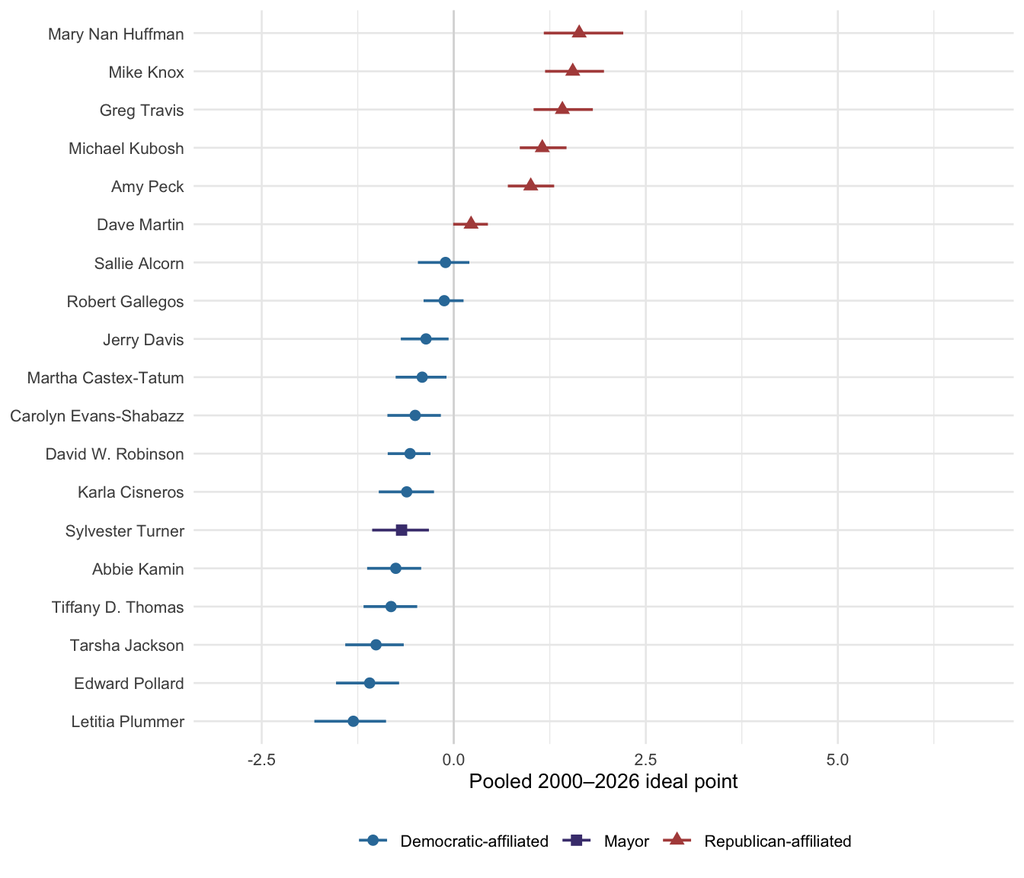

2020–2023 council on the pooled 2000–2026 axis.

**2016–2019**

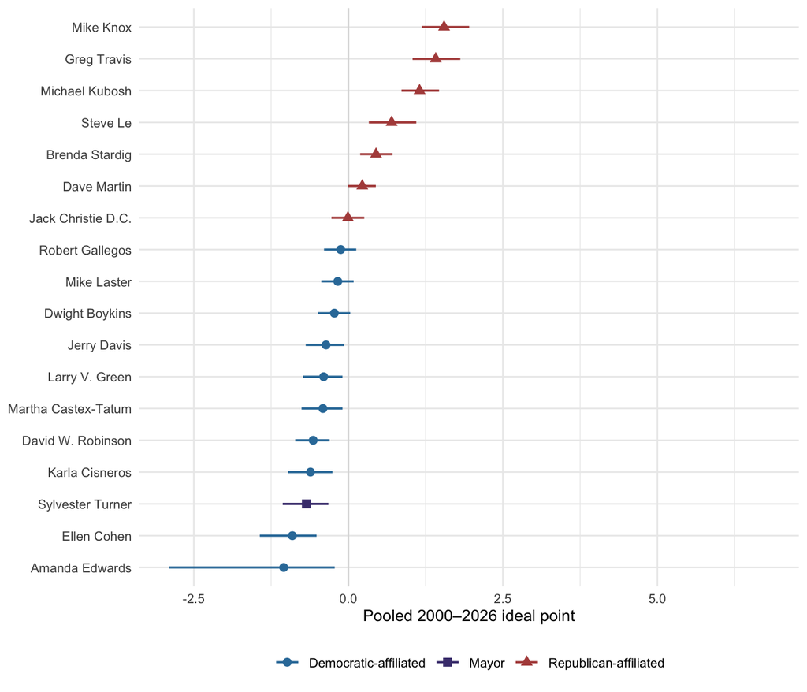

2016–2019 council, the first four-year term.

### Earlier two-year councils

The 2014–2015 council was the last elected for a two-year term. These tabs continue backward by **regular election**, not by an arbitrary statistical window.

**2014–2015**

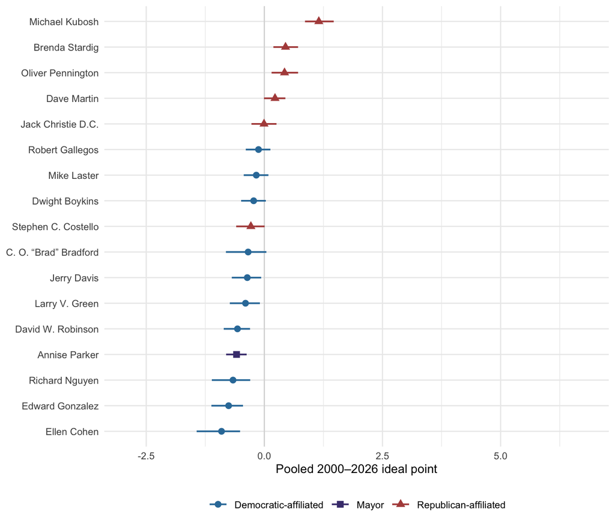

2014–2015 council.

**2012–2013**

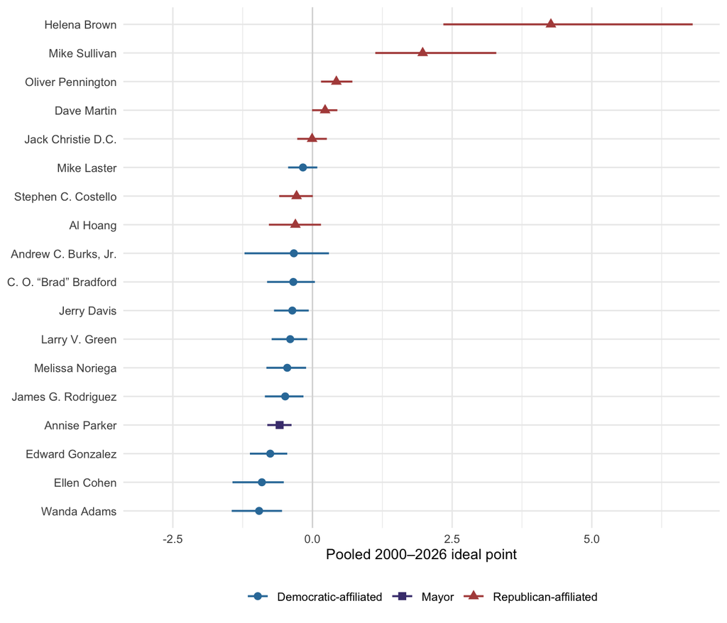

2012–2013 council.

**2010–2011**

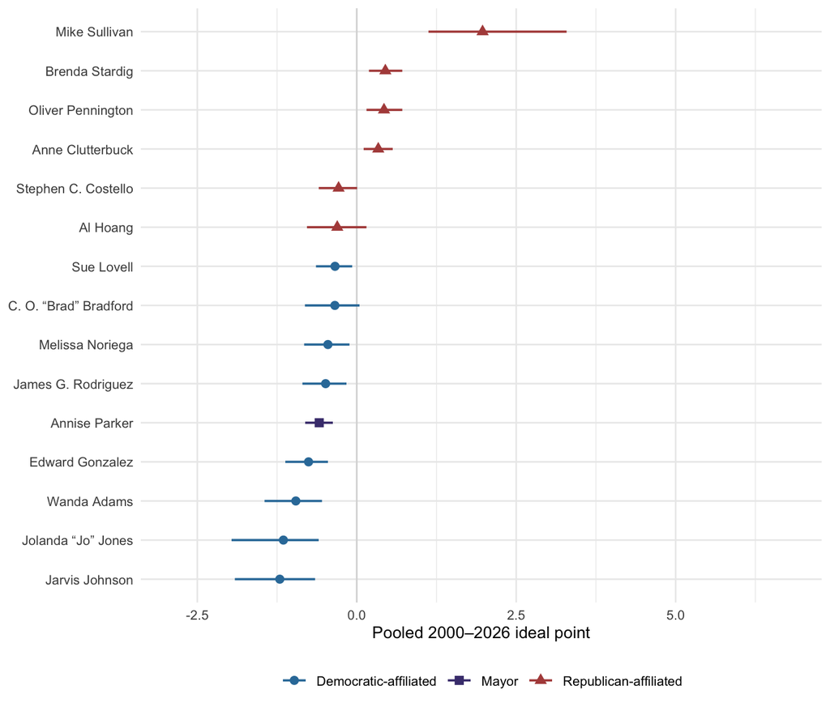

2010–2011 council.

**2008–2009**

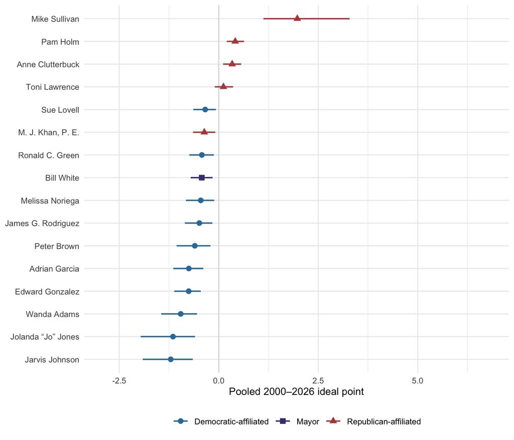

2008–2009 council.

**2006–2007**

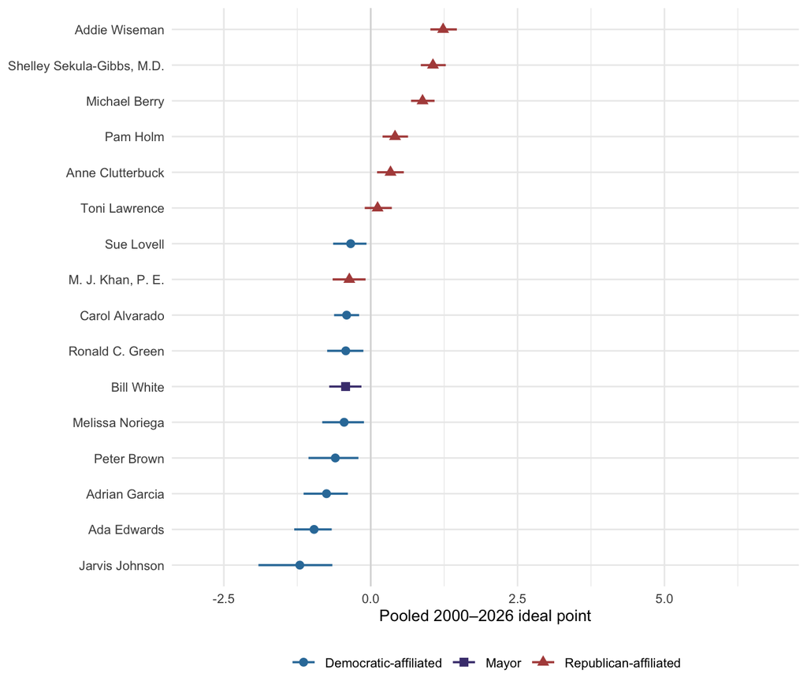

2006–2007 council.

**2004–2005**

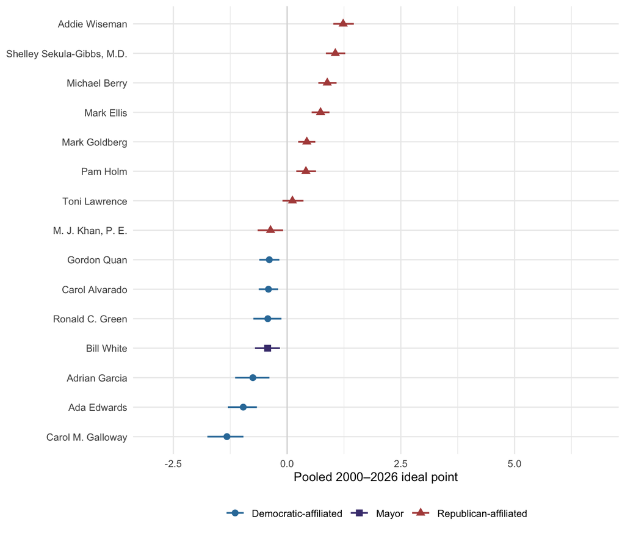

2004–2005 council.

**2002–2003**

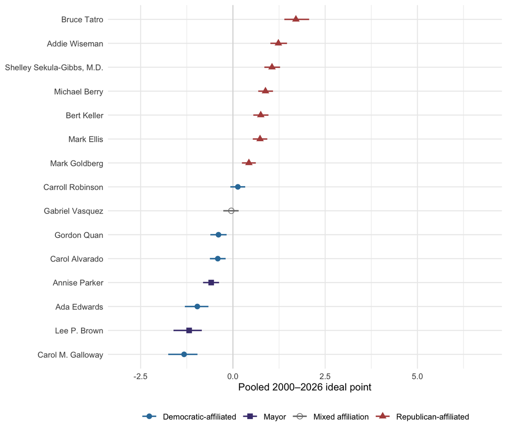

2002–2003 council, observed throughout the term.

**2000–2001**

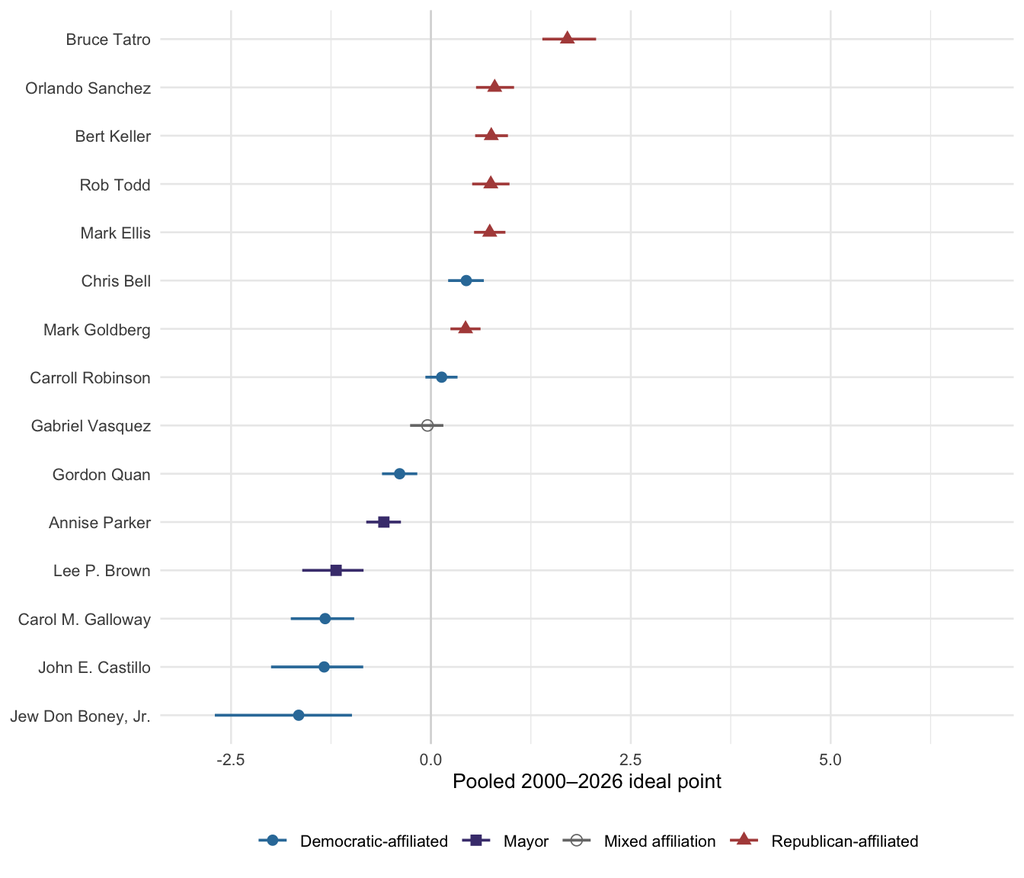

2000–2001 council, including Mayor Lee P. Brown.

| Council | Elected in | Term years | Members | Divided actions | Observed votes |
| --- | --- | --- | --- | --- | --- |
| 2024–2027 | 2,023 | 4 | 17 | 42 | 617 |
| 2020–2023 | 2,019 | 4 | 19 | 116 | 1,878 |
| 2016–2019 | 2,015 | 4 | 18 | 49 | 767 |
| 2014–2015 | 2,013 | 2 | 17 | 70 | 1,092 |
| 2012–2013 | 2,011 | 2 | 18 | 37 | 595 |
| 2010–2011 | 2,009 | 2 | 15 | 29 | 410 |
| 2008–2009 | 2,007 | 2 | 16 | 25 | 346 |
| 2006–2007 | 2,005 | 2 | 16 | 97 | 1,375 |
| 2004–2005 | 2,003 | 2 | 15 | 82 | 1,168 |
| 2002–2003 | 2,001 | 2 | 15 | 227 | 3,256 |
| 2000–2001 | 1,999 | 2 | 15 | 165 | 2,281 |

The 2000–2001 council contributes **165 divided actions** and the 2002–2003 council **227**, compared with 116 in 2020–2023. All 15 observed officials in each of the two earliest councils clear the seven-vote threshold. Brown, Chris Bell, Orlando Sanchez and Jew Don Boney Jr. have substantial early vote histories. **Shelley Sekula-Gibbs** sits at 1.06, and **Addie Wiseman** at 1.23 on the pooled scale.

### Individual members and policy controversies

Among recent members, **Fred Flickinger** (2.74), **Greg Travis** (1.41), **Mike Knox** (1.55), and **Mary Nan Huffman** (1.63) sit at the positive end. Flickinger’s interval is relatively wide because he entered office in 2024. **Letitia Plummer** (-1.31), **Edward Pollard** (-1.09), **Tarsha Jackson** (-1.01), and **Tiffany Thomas** (-0.82) sit at the negative end. The following independently checked examples show what some of their opposing votes concerned:

- **Conservation districts (April 2023):** rules intended to slow redevelopment and displacement in historically Black and Latino neighborhoods passed 13–4; Peck, Martin, Huffman, and Knox opposed the restrictions on property owners. [Houston Chronicle](https://www.houstonchronicle.com/politics/houston/article/houston-creates-conservation-districts-17878204.php); [Houston Public Media](https://www.houstonpublicmedia.org/articles/news/city-of-houston/2023/04/05/448401/houston-city-council-approves-conservation-districts-with-hopes-of-protecting-six-historic-neighborhoods/)
- **Gun buyback funding (August 2022):** $539,000 in federal relief money for gift cards passed 12–4 over Peck, Huffman, Knox, and Kubosh, amid disagreement about whether anonymous buybacks reduce gun crime. [KPRC](https://www.click2houston.com/news/local/2022/08/23/houston-council-seeking-to-approve-539000-for-future-gun-buyback-programs-research-shows-it-doesnt-deter-gun-crime/)
- **Property tax rate (September 2023):** council cut the rate slightly, though higher appraisals increased total revenue. Peck, Huffman, Knox, and Kubosh voted no on the 12–4 levy. [Houston Chronicle](https://www.houstonchronicle.com/politics/houston/article/houston-tax-rate-cut-increase-18365317.php)
- **Disaster-recovery housing (August 2025):** an amendment moved $50 million of federal storm-recovery funds from power generation to home repair. The amended plan passed 12–3, with Peck, Flickinger, and Huffman opposed. [KPRC](https://www.click2houston.com/news/local/2025/08/13/houston-city-council-approves-amended-disaster-recovery-plan-allocates-100-million-for-housing-repair/)
- **I-45 right-of-way sale (January 2025):** the city sold land by White Oak Bayou to TxDOT for the contested highway project. The recorded 9–7 split placed Plummer, Pollard, Jackson, Thomas, Kamin, Evans-Shabazz, and Castillo in opposition; Peck, Huffman, Flickinger, and Mayor Whitmire supported the sale. [ABC13](https://abc13.com/post/city-houston-approves-controversial-sale-land-txdot-45/14858675/)

These cases suggest a spectrum involving fiscal and land-use regulation, spending priorities, and highway development. They illustrate the dimension; they do not establish that every divided vote has the same policy meaning. Tallies above follow the official roll calls; news summaries occasionally differ.

### Citywide and district seats

Houston elects five at-large council members **citywide**, while eleven represent geographic districts; the mayor is elected citywide too ([City Council](https://houstontx.gov/council/)). A citywide electorate could reward broader coalitions and pull at-large members toward the mayor, but it does not require every winner to be a centrist. The [city’s February 2024 roster map](https://www.houstontx.gov/council/maps2024/alldistricts.pdf) identifies the seats used here. This comparison is confined to the 2023-elected council.

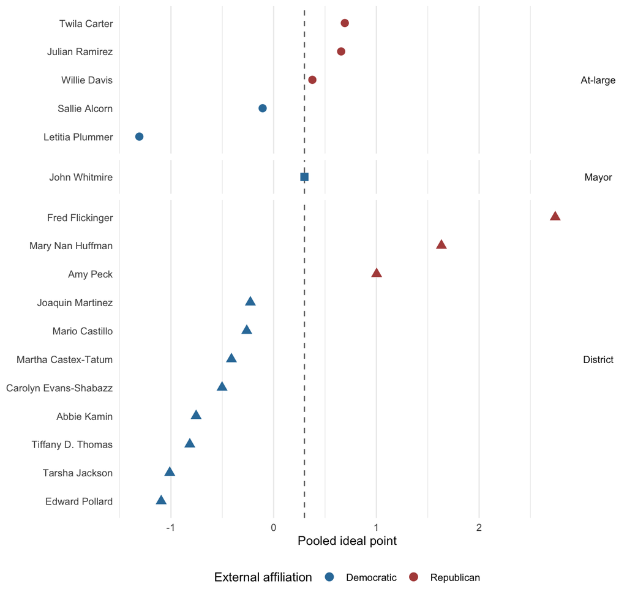

The 2023-elected council: five citywide at-large members, eleven district members, and Mayor Whitmire. The dashed line marks Whitmire’s pooled position. Colors are independently researched party affiliation; positions come only from roll calls.

| Office type | Officials | Median position | Median distance to Whitmire |
| --- | --- | --- | --- |
| At-large | 5 | 0.38 | 0.39 |
| District | 11 | -0.41 | 1.05 |

### 2024 presidential vote by council district

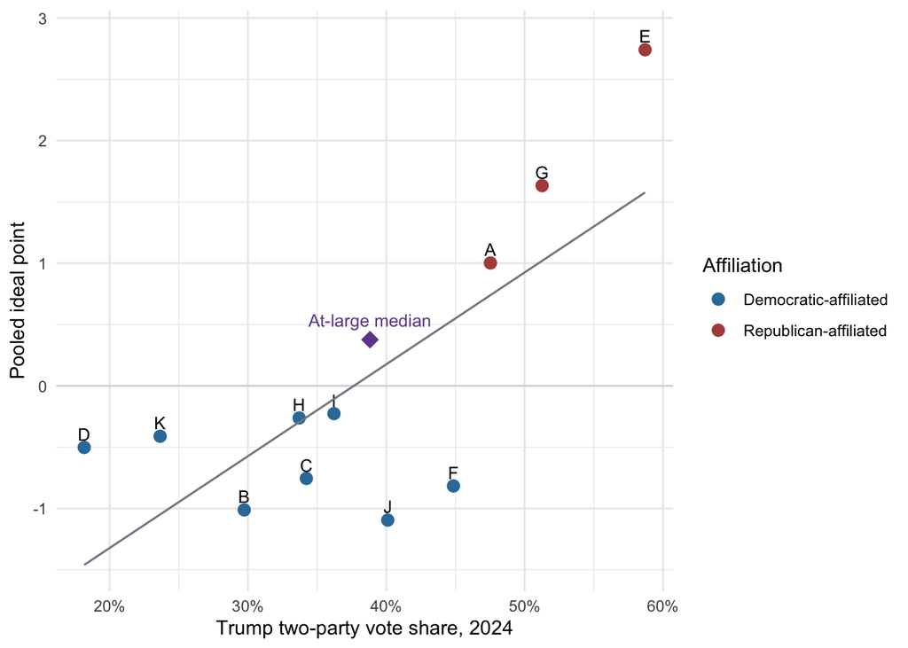

The plot combines [published 2024 precinct results](https://github.com/nytimes/presidential-precinct-map-2024) with council-district boundaries. Because many precincts cross district lines, we allocate their votes by the share of precinct area in each district; this assumes voters are spread evenly within each precinct. The purple diamond is the **median of the five at-large members’ pooled positions** (0.38), located at Houston’s estimated citywide Trump two-party share (38.8%). The citywide share comes from **summing allocated Democratic and Republican votes across all eleven districts**, not averaging district percentages. It is approximate for the same split-precinct reason. At-large members have no individual district point, and the median marker is not an additional officeholder or observation in the fitted line. Among the eleven district seats alone, Trump share correlates **0.73** with the pooled ideal point. The three most Republican districts, E, G, and A, elected Republican-affiliated district members. F and J are notable exceptions: their members, Thomas and Pollard, lie near the negative end despite comparatively competitive district presidential results. This comparison concerns the district members serving at the 2024 election. The small sample and area allocation make it supporting evidence rather than a precise district-level estimate.

### 2023 mayoral runoff by council district

The [official December 2023 mayoral runoff canvass](https://www.houstontx.gov/citysec/elections/120923.pdf) offers a city-election check against the eleven district members elected in the same cycle. John Whitmire’s share against Sheila Jackson Lee is higher in districts represented by members toward the positive end of the pooled voting scale. These are the members who **took office in January 2024**, not the council serving on runoff day; neither candidate’s party affiliation appeared on the nonpartisan mayoral ballot.

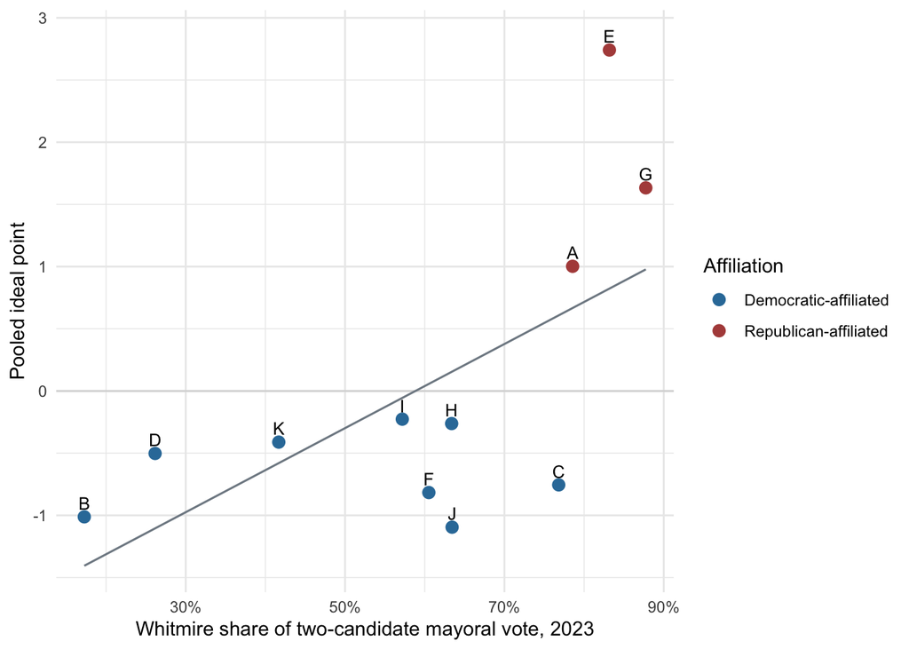

December 2023 mayoral runoff by district: Whitmire’s share of the two candidates’ votes against the pooled ideal point of the district member elected in 2023. Colors show independently researched affiliation. The line uses district members only.

The district relationship is **0.63** across eleven seats. The canvass’s three county totals reconcile exactly; the primary district series assigns **98.1%** of the city’s 201,528 candidate votes. It omits twelve precincts marked as crossing council districts in the [City’s dated precinct list](https://houstontx.gov/citysec/precincts.pdf) and 111 Montgomery County votes without matching geography. Other precincts are assigned to their predominant district polygon, so this is a near-exact geographic check rather than a certified district canvass. Allocating split-precinct votes by area instead gives a correlation of **0.63**. The close agreement makes the broad result less sensitive to this allocation choice, but neither method measures where individual voters within a split precinct lived. The technical appendix gives the construction and coverage details.

### Earlier presidential elections

The comparison for **2016 and 2020** uses the eleven-district council map in force from the 2013 election through 2023—not the post-redistricting map used above for 2024. Each point is matched to the member **actually serving on presidential Election Day**. In 2020, that means Jerry Davis in District B: its delayed runoff did not elect Tarsha Jackson until December. The table reports a separate district-level relationship for each year, not a pooled correlation across changing maps and councils.

| Year | Districts | Pearson r |
| --- | --- | --- |
| 2016 | 11 | 0.63 |
| 2020 | 11 | 0.58 |
| 2024 | 11 | 0.73 |

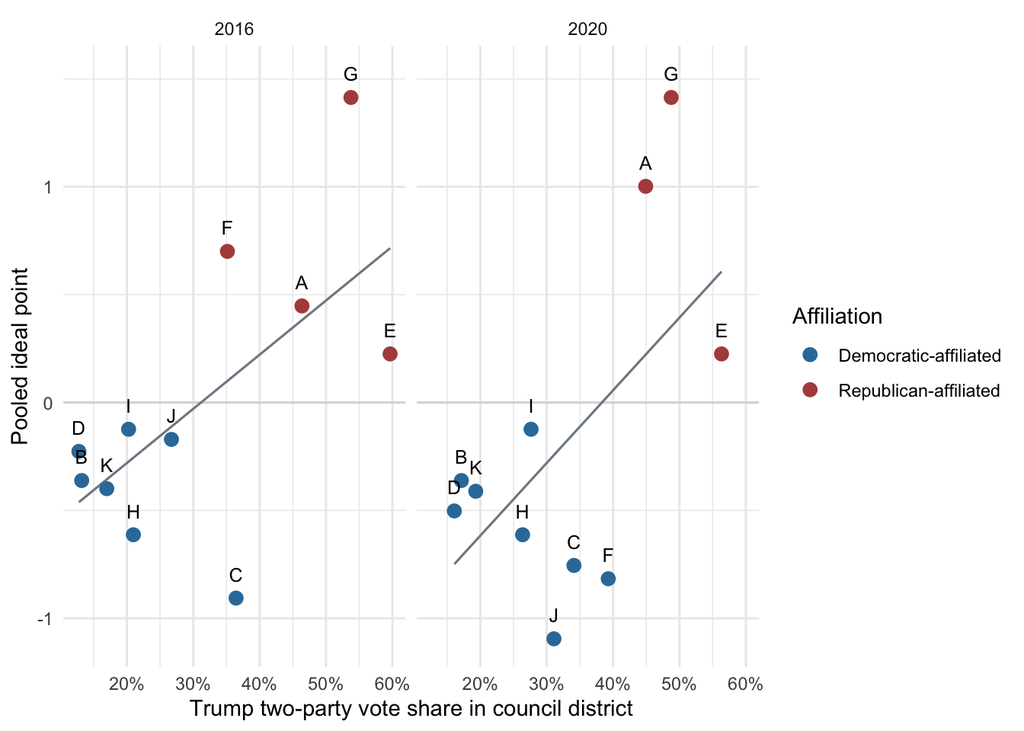

Earlier presidential elections: contemporaneous council districts and Election Day district members. Lines are descriptive within-year fits.

The [2016 election-time precinct boundaries](https://data.capitol.texas.gov/dataset/6381bd0b-3ad4-4556-bb3f-6c579a60d00a) come from the Texas Legislative Council and were joined to [precinct returns](https://github.com/openelections/openelections-data-tx); their Democratic and Republican totals match the [Texas Secretary of State’s county recaps](https://elections.sos.state.tx.us/index.htm) in Harris, Fort Bend, and Montgomery. The [2020 geocoded precinct results](https://github.com/TheUpshot/presidential-precinct-map-2020) also reconcile to county candidate totals. The historical council district map was derived from City of Houston GIS and represents the earlier plan. As in 2024, split precincts are apportioned by area, which assumes uniform voter density. These associations provide external comparisons for the members serving at each election. We stop at 2016 because still-earlier elections require separately verified precinct and council-map vintages.

### Partisan affiliation

Houston’s municipal ballots are nonpartisan. **The roll-call votes do not supply party labels; we assembled and coded them separately** for all 77 fitted officials, with a source and an evidence type for each person. The four types — `party_record`, `party_organization`, `self_identified`, `reported` — describe what kind of source a label rests on, not how strong it is. `party_record` means a documented partisan candidacy or party office, not voter registration or a council ballot line. A GOP endorsement is weaker evidence of political leaning, not proof of membership. For example, [Mary Nan Huffman’s 2020 Republican primary candidacy](https://files.harrisvotes.com/harrisvotes/prd/HISTORY/20200303/RepublicanCumulative.pdf) is a party record; the [Harris County GOP’s 2023 endorsements](https://www.harriscountygop.com/harris-county-gop-endorsed-candidates-win-big-on-election-day/) of Flickinger, Ramirez, Davis, and Carter are endorsements. The early members include [Chris Bell, elected to Congress as a Democrat](https://history.house.gov/People/Listing/B/BELL%2C-Chris-%28B001241%29/), [Orlando Sanchez on an official Republican primary ballot](https://files.harrisvotes.com/harrisvotes/prd/HISTORY/20180306/cumulative/Rep/cumulative.pdf), and [Bert Keller on a Republican primary ballot](https://ivoterguide.com/candidate/60884/race/288/election/871). Contemporary reporting identifies Brown as a Democrat and Bruce Tatro and Rob Todd as Republicans; party-organization and primary-election records support Boney, Castillo, and Robinson as Democrats. **Gabriel Vasquez changed from Democratic to Republican affiliation while serving**, so his affiliation is recorded as two dated rows and he is omitted from fixed two-party comparisons. The evidence ledger in the technical appendix lists every source. These labels never enter the vote model as data, priors, or fixed positions. The reported solution comes from a start derived only from the votes; a separate chain started from party labels reaches the same solution, as detailed in the appendix. We found no winning Houston DSA-endorsed council candidate or formal ideological council caucus.

| External affiliation evidence | Officials |
| --- | --- |
| Democratic | 45 |
| Mixed | 1 |
| Republican | 31 |

Focused follow-up found a [2010 Republican primary candidacy for Addie Wiseman](https://elections.sos.state.tx.us/elchist148_state.htm), [Larry Green’s interest in the Democratic nomination for county commissioner](https://www.houstonchronicle.com/politics/houston/article/Resign-to-run-law-now-applies-to-elected-city-6787701.php), and an [explicit Republican characterization of M. J. Khan](https://www.houstonchronicle.com/politics/houston/article/houston-mayor-candidates-gun-buybacks-bike-lanes-18395207.php). Green’s evidence is a news account rather than a formal party filing and is typed `reported`. Two further cases are supported by distinct, non-voting evidence: an [archived Carol Mims Galloway biography](https://web.archive.org/web/20250917114837/https://texas.comcast.com/carol-mims-galloway/) lists membership in Harris County Black Democrats, and a [contemporaneous report of the Harris County Democratic Party’s 2015 endorsement slate](https://www.offthekuff.com/wp/?p=70979) identifies District F’s Richard Nguyen among its Democratic candidates. Galloway’s club membership is self-reported and Nguyen’s party slate is reported secondhand, so neither is typed `party_record`: Galloway is `self_identified` and Nguyen `reported`. A [contemporaneous *Texas Monthly* profile](https://web.archive.org/web/20210513000446/https://www.texasmonthly.com/news-politics/here-comes-trouble/) identifies **Michael Kubosh** as a Republican and explains his 2006 Democratic Senate candidacy as a tactical ballot choice. A [2019 *Houston Chronicle* profile](https://web.archive.org/web/20230208205501/https://www.houstonchronicle.com/news/houston-texas/houston/article/Houston-council-runoff-foes-are-opposites-in-14867953.php) reports GOP endorsements and Republican ballots in eight of nine earlier primaries, while noting that he now rejects party labels. We classify him Republican-affiliated from this combined reporting, not as a Republican party-record case: no Republican candidacy or party office is documented. No label here is assigned by voting score, district, or reputation. Individual sources and evidence types are listed in the technical appendix.

| Affiliation group | In group | Others | Median: group | Median: others | Median difference |
| --- | --- | --- | --- | --- | --- |
| Republican-affiliated (all evidence) | 31 | 45 | 0.74 | -0.57 | 1.30 |
| Republican candidacy or party office | 13 | 63 | 1.06 | -0.39 | 1.45 |
| Democratic-affiliated (all evidence) | 45 | 31 | -0.57 | 0.74 | -1.30 |

The count table covers **all 77 officials**. The median-comparison table covers the **76 assigned a single Democratic or Republican affiliation**, excluding Vasquez’s documented party switch. “Others” means everyone else among those 76; in the candidacy/office row it also includes Republicans whose evidence is an endorsement, roster, or reporting. These group medians are descriptive comparisons of small, unevenly served groups.

**Dave Martin**, classified Republican only from reporting, is a conspicuous exception: he voted with the Turner-era majority. Kubosh is included as Republican-affiliated on independent reporting, not because his score is positive.

### Organizational endorsements, 2015 and 2023

Four organizations were researched **separately**, with no combined “progressive” label: the [Texas Gulf Coast Area Labor Federation](https://www.gcaflcio.org/endorsements), [Houston LGBTQ+ Political Caucus](https://www.thecaucus.org/wp-content/uploads/2023/08/Houston-LGBTQ-Political-Caucus-PAC-Endorses-in-the-2023-Municipal-Election-FINAL.pdf), [Texas Organizing Project (TOP PAC)](https://organizetexas.org/2023/08/top-announces-endorsed-candidates-for-houston-city-council/), and Our Revolution Harris County. The first two published full 2023 municipal slates; TOP’s recovered list is short, and no verifiable Our Revolution Houston municipal candidate slate was found. Earlier endorsement records are uneven, so absence from an unrecovered slate is **unknown**, not “not endorsed.” Democratic clubs are not part of these indicators. The candidate-level source ledger retains both matched officeholders and challengers who never entered the 77-person fit.

For a same-election comparison, the table below uses only the **17 fitted officials who voted in the first year of the council elected in 2023**. It compares their pooled scores with each organization’s *November general-election* list; later runoff endorsements are retained in the ledger but not substituted for general-election choices. All listed fitted officials are Democratic-affiliated. Labor and the Caucus each backed seven, but not the same seven: labor backed Whitmire and Pollard, while the Caucus backed Castillo and Thomas. TOP backed just Plummer and Jackson among fitted winners; it also backed Lloyd Ford against incumbent Carolyn Evans-Shabazz. The separate lists therefore retain real disagreements, although TOP’s small group is descriptive, not a statistical test.

| Organization | Listed among 17 | Democrats listed | Republicans listed | Median gap: listed − not listed | Within-D median gap |
| --- | --- | --- | --- | --- | --- |
| Labor federation | 7 | 7 | 0 | -1.02 | +0.11 |
| LGBTQ+ Caucus | 7 | 7 | 0 | -1.02 | +0.21 |
| TOP PAC | 2 | 2 | 0 | -1.05 | -0.75 |
| Our Revolution | 0 | 0 | 0 | — | — |

Negative gaps indicate a more negative pooled voting position for the listed candidates. Labor and Caucus endorsements distinguish the two parties in this council, but **hardly separate the Democrats from one another**. TOP’s two listed winners sit farther left even among Democrats, though the very small count and its partial published list make that finding tentative. Our Revolution is unmeasured, not a zero-endorsement comparison. Further descriptive measures are in the technical appendix.

A recovered [complete 2015 Caucus slate](https://www.offthekuff.com/wp/?p=68966) offers an earlier check: eight of the 17 officials observed in the 2016 council’s first year were endorsed, all Democratic-affiliated. Their median pooled position is 0.93 units more negative than that of the nine not listed. Among Democrats alone, the gap is 0.06. As in 2023, the Caucus endorsement largely distinguishes partisan coalitions rather than sharply sorting Democrats.

### Aggregate party patterns

The distributions below include the 76 officials assigned a single party affiliation, once per person. Vasquez’s documented switch is omitted. The smoothed curves taper to zero at each group’s lowest-scoring member and do not extend farther left. The lowest-scoring Republican-affiliated official is **M. J. Khan** (-0.36). The display runs from −2.5 through +2.5; 2 high-positive Republican scores lie beyond the window but still enter the density estimate. These are descriptions of 31 Republican-affiliated and 45 Democratic-affiliated points, not population distributions; service periods are very unequal.

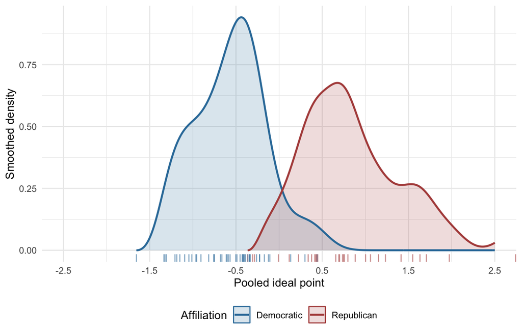

Distribution of the pooled ideal-point posterior means by externally researched affiliation. Each official contributes one score, regardless of years served.

The next plot shows each party’s **median pooled ideal point among members observed in each elected council**, beginning with 2000–2001. The two curves share one vertical scale, and each member contributes once to a council where they cast at least one qualifying vote. Vasquez is omitted because his party changed during service. Point size indicates the number of members in each party’s council group; lighter dashed curves summarize the broad direction.

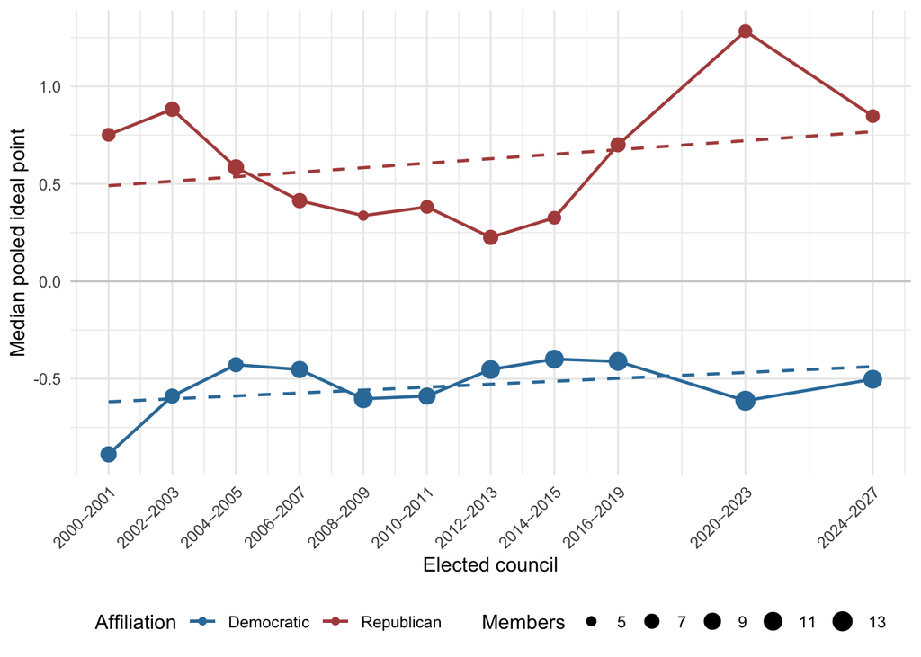

The party medians move farther apart in later elected councils, especially 2020–2023, consistent with polarization through member replacement. The dashed straight lines summarize each party’s trend across councils. The current council is only partly observed.

The next plot compares the first observed elected council with 2020–2023, left to right in time. Each panel shows a density curve for each party on the same ideal-point axis; small ticks mark individual officials. The curves stop at each group’s most extreme observed members, and each is scaled to unit area. They make the growing separation easier to see, but the small groups are not population distributions. Gabriel Vasquez, who changed party affiliation during his service, is omitted from these fixed-party curves.

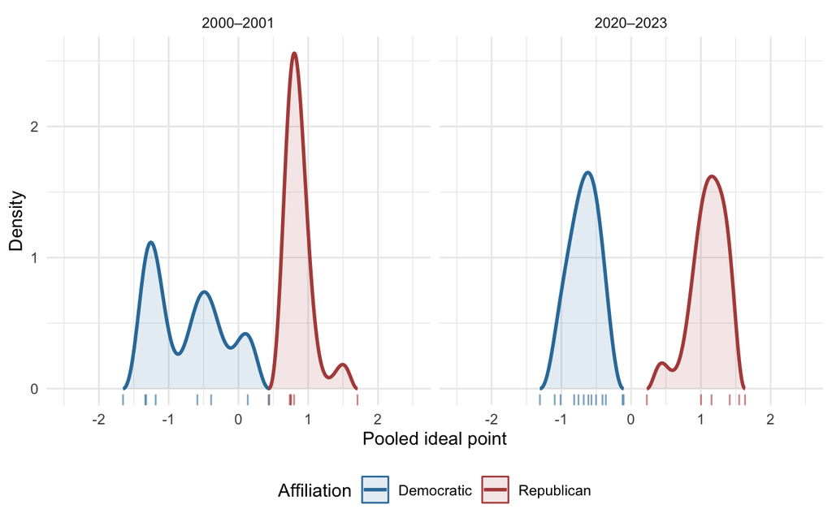

Party-score densities in two elected councils. Curves use the same bandwidth and axes; small bottom ticks show individual scores. Vasquez’s mixed affiliation is excluded.

## Interpretation and limits

Houston’s pooled voting spectrum tracks researched party affiliations and district electorates across five mayoralties. A Texas common-space placement is not supported by the six all-Democratic bridges available here. Detailed construction, estimation and bridge limits are in the technical appendix and bridge diagnostic.